# HW 101025 Yiwei Gu

install package through console

```r
airlines <- nycflights13::airlines
airports <- nycflights13::airports
flights  <- nycflights13::flights
planes   <- nycflights13::planes
weather  <- nycflights13::weather
```

```r
library(dplyr)
library(ggplot2)
library(leaflet)
```

#1:

```r
top_dest <- flights %>%
  group_by(dest) %>%
  summarise(flight_count = n()) %>%
  top_n(10, flight_count) %>%
  arrange(desc(flight_count))
top_dest
```

```
# A tibble: 10 × 2
   dest  flight_count
   <chr>        <int>
 1 ORD          17283
 2 ATL          17215
 3 LAX          16174
 4 BOS          15508
 5 MCO          14082
 6 CLT          14064
 7 SFO          13331
 8 FLL          12055
 9 MIA          11728
10 DCA           9705
```

Ans: The top 10 most popular destinations for flights departing from New York City in 2013 were mostly major U.S. hubs and popular cities. The top two popular destinations were Chicago O’Hare and Atlanta Hartsfield-Jackson, each receiving over 17,000 flights. Los Angeles International and Boston Logan also had a high volume, with over 15,000 flights each. Other frequently traveled destinations included Orlando, Charlotte, San Francisco, Fort Lauderdale, Miami, and Washington D.C. (Reagan National).

```r
time_vars <- c("dep_time", "arr_time")
flights_time <- flights
for(var in time_vars){
  flights_time[, paste0(var, "_category")] <- case_when(
    flights_time[[var]] >= 0 & flights_time[[var]] < 600   ~ "early morning",
    flights_time[[var]] >= 600 & flights_time[[var]] < 1200 ~ "morning",
    flights_time[[var]] >= 1200 & flights_time[[var]] < 1800 ~ "afternoon",
    flights_time[[var]] >= 1800 & flights_time[[var]] <= 2359 ~ "evening",
    TRUE ~ NA_character_
  )
}
head(flights_time[, c("dep_time_category", "arr_time_category")])
```

```
# A tibble: 6 × 2
  dep_time_category arr_time_category
  <chr>             <chr>
1 early morning     morning
2 early morning     morning
3 early morning     morning
4 early morning     morning
5 early morning     morning
6 early morning     morning
```

#3:

```r
planes_multi <- flights %>%
  filter(!is.na(tailnum)) %>%
  count(tailnum, carrier) %>%
  group_by(tailnum) %>%
  summarise(num_airlines = n(),
            airlines = paste(carrier, collapse = ", ")) %>%
  filter(num_airlines > 1)
num_planes <- nrow(planes_multi)
planes_multi
```

```
# A tibble: 17 × 3
   tailnum num_airlines airlines
   <chr>          <int> <chr>
 1 N146PQ             2 9E, EV
 2 N153PQ             2 9E, EV
 3 N176PQ             2 9E, EV
 4 N181PQ             2 9E, EV
 5 N197PQ             2 9E, EV
 6 N200PQ             2 9E, EV
 7 N228PQ             2 9E, EV
 8 N232PQ             2 9E, EV
 9 N933AT             2 DL, FL
10 N935AT             2 DL, FL
11 N977AT             2 DL, FL
12 N978AT             2 DL, FL
13 N979AT             2 DL, FL
14 N981AT             2 DL, FL
15 N989AT             2 DL, FL
16 N990AT             2 DL, FL
17 N994AT             2 DL, FL
```

```r
num_planes
```

```
[1] 17
```

#4: The missing relationship in the diagram is that each weather observation is linked to a specific airport. This relationship exists through the origin field in the weather table, which corresponds to the faa field in the airports table. To represent this in the diagram, an arrow should be drawn from weather.origin to airports.faa. This indicates that each weather record belongs to a specific airport, establishing a foreign key relationship between the two tables.

#5:

```r
names <- c("year", "month", "day", "hour", "origin")
weather$weather_id <- ""
for (var in names) {
  weather$weather_id <- paste0(weather$weather_id,
                           ifelse(weather$weather_id == "", "", "-"),
                           weather[[var]])
}

num_dupes <- sum(duplicated(weather$weather_id))
cat("Number of duplicated weather_id values:", num_dupes, "\n")
```

```
Number of duplicated weather_id values: 3
```

```r
unique(weather$weather_id[duplicated(weather$weather_id)])
```

```
[1] "2013-11-3-1-EWR" "2013-11-3-1-JFK" "2013-11-3-1-LGA"
```

After creating a new variable weather_id by combining year, month, day, hour, and origin, I found 3 duplicated weather_id values (2013-11-3-1 at EWR, JFK, and LGA). These duplicates exist because daylight saving time ended on November 3, 2013, causing the 1 AM hour to occur twice. Since we used only year, month, day, hour, and origin, these two distinct 1 AM observations appear as duplicates.

#6:

```r
flights_weather <- merge(
  x     = flights,
  y     = weather,
  by    = c("time_hour", "origin"),
  all.x = TRUE,
  all.y = FALSE
)
```

```r
dim(flights_weather)
```

```
[1] 336776     33
```

```r
head(flights_weather[, c("origin", "time_hour", "dep_delay", "temp", "wind_speed", "precip")])
```

```
  origin           time_hour dep_delay  temp wind_speed precip
1    EWR 2013-01-01 05:00:00         2 39.02   12.65858      0
2    EWR 2013-01-01 05:00:00        -4 39.02   12.65858      0
3    JFK 2013-01-01 05:00:00         0 39.02   14.96014      0
4    JFK 2013-01-01 05:00:00         2 39.02   14.96014      0
5    JFK 2013-01-01 05:00:00        -1 39.02   14.96014      0
6    LGA 2013-01-01 05:00:00         4 39.92   14.96014      0
```

```r
flights_data <- flights
weather_data <- weather

dupes_weather <- weather_data[duplicated(weather_data[, c("time_hour", "origin")]), ]
cat("Duplicated (time_hour, origin) in weather:", nrow(dupes_weather), "\n")
```

```
Duplicated (time_hour, origin) in weather: 0
```

```r
if (nrow(dupes_weather) > 0) {
  weather_data <- weather_data[!duplicated(weather_data[, c("time_hour", "origin")]), ]
  flights_weather <- merge(
    x     = flights_data,
    y     = weather_data,
    by    = c("time_hour", "origin"),
    all.x = TRUE,
    all.y = FALSE
  )
}

cat("Final number of rows:", nrow(flights_weather), "\n")
```

```
Final number of rows: 336776
```

```r
head(flights_weather[, c("origin", "time_hour", "dep_delay", "temp", "wind_speed", "precip")], 5)
```

```
  origin           time_hour dep_delay  temp wind_speed precip
1    EWR 2013-01-01 05:00:00         2 39.02   12.65858      0
2    EWR 2013-01-01 05:00:00        -4 39.02   12.65858      0
3    JFK 2013-01-01 05:00:00         0 39.02   14.96014      0
4    JFK 2013-01-01 05:00:00         2 39.02   14.96014      0
5    JFK 2013-01-01 05:00:00        -1 39.02   14.96014      0
```

```r
flights_weather <- flights_weather %>%
  select(-year.y, -month.y, -day.y, -hour.y) %>%
  rename(
    year = year.x,
    month = month.x,
    day = day.x,
    hour = hour.x
  )
```

2: check the size of the data:

```r
dim(flights_weather)
```

```
[1] 336776     29
```

3: examine the variables and their types

```r
str(flights_weather)
```

```
'data.frame':   336776 obs. of  29 variables:
 $ time_hour     : POSIXct, format: "2013-01-01 05:00:00" "2013-01-01 05:00:00" ...
 $ origin        : chr  "EWR" "EWR" "JFK" "JFK" ...
 $ year          : int  2013 2013 2013 2013 2013 2013 2013 2013 2013 2013 ...
 $ month         : int  1 1 1 1 1 1 1 1 1 1 ...
 $ day           : int  1 1 1 1 1 1 1 1 1 1 ...
 $ dep_time      : int  517 554 559 542 544 533 732 629 624 643 ...
 $ sched_dep_time: int  515 558 559 540 545 529 645 630 630 646 ...
 $ dep_delay     : num  2 -4 0 2 -1 4 47 -1 -6 -3 ...
 $ arr_time      : int  830 740 702 923 1004 850 1011 824 909 922 ...
 $ sched_arr_time: int  819 728 706 850 1022 830 941 833 840 940 ...
 $ arr_delay     : num  11 12 -4 33 -18 20 30 -9 29 -18 ...
 $ carrier       : chr  "UA" "UA" "B6" "AA" ...
 $ flight        : int  1545 1696 1806 1141 725 1714 1111 1019 4626 556 ...
 $ tailnum       : chr  "N14228" "N39463" "N708JB" "N619AA" ...
 $ dest          : chr  "IAH" "ORD" "BOS" "MIA" ...
 $ air_time      : num  227 150 44 160 183 227 145 91 190 146 ...
 $ distance      : num  1400 719 187 1089 1576 ...
 $ hour          : num  5 5 5 5 5 5 6 6 6 6 ...
 $ minute        : num  15 58 59 40 45 29 45 30 30 46 ...
 $ temp          : num  39 39 39 39 39 ...
 $ dewp          : num  28 28 27 27 27 ...
 $ humid         : num  64.4 64.4 61.6 61.6 61.6 ...
 $ wind_dir      : num  260 260 260 260 260 250 240 240 240 240 ...
 $ wind_speed    : num  12.7 12.7 15 15 15 ...
 $ wind_gust     : num  NA NA NA NA NA ...
 $ precip        : num  0 0 0 0 0 0 0 0 0 0 ...
 $ pressure      : num  1012 1012 1012 1012 1012 ...
 $ visib         : num  10 10 10 10 10 10 10 10 10 10 ...
 $ weather_id    : chr  "2013-1-1-5-EWR" "2013-1-1-5-EWR" "2013-1-1-5-JFK" "2013-1-1-5-JFK" ...
```

dep_delay: numeric — departure delay in minutes. arr_delay: numeric — arrival delay in minutes. origin: factor/character — departure airport (JFK, LGA, EWR). dest: factor/character — destination airport code. time_hour: POSIXct — scheduled time of flight. Weather variables: temp, dewp, humid — temperature, dew point, humidity. wind_speed, wind_gust, precip, visib — wind, precipitation, visibility

4; look at the top and bottom of the data

```r
head(flights_weather, 5)
```

```
            time_hour origin year month day dep_time sched_dep_time dep_delay
1 2013-01-01 05:00:00    EWR 2013     1   1      517            515         2
2 2013-01-01 05:00:00    EWR 2013     1   1      554            558        -4
3 2013-01-01 05:00:00    JFK 2013     1   1      559            559         0
4 2013-01-01 05:00:00    JFK 2013     1   1      542            540         2
5 2013-01-01 05:00:00    JFK 2013     1   1      544            545        -1
  arr_time sched_arr_time arr_delay carrier flight tailnum dest air_time
1      830            819        11      UA   1545  N14228  IAH      227
2      740            728        12      UA   1696  N39463  ORD      150
3      702            706        -4      B6   1806  N708JB  BOS       44
4      923            850        33      AA   1141  N619AA  MIA      160
5     1004           1022       -18      B6    725  N804JB  BQN      183
  distance hour minute  temp  dewp humid wind_dir wind_speed wind_gust precip
1     1400    5     15 39.02 28.04 64.43      260   12.65858        NA      0
2      719    5     58 39.02 28.04 64.43      260   12.65858        NA      0
3      187    5     59 39.02 26.96 61.63      260   14.96014        NA      0
4     1089    5     40 39.02 26.96 61.63      260   14.96014        NA      0
5     1576    5     45 39.02 26.96 61.63      260   14.96014        NA      0
  pressure visib     weather_id
1   1011.9    10 2013-1-1-5-EWR
2   1011.9    10 2013-1-1-5-EWR
3   1012.1    10 2013-1-1-5-JFK
4   1012.1    10 2013-1-1-5-JFK
5   1012.1    10 2013-1-1-5-JFK
```

```r
tail(flights_weather, 5)
```

```
                 time_hour origin year month day dep_time sched_dep_time
336772 2013-12-31 23:00:00    EWR 2013    12  31     2328           2330
336773 2013-12-31 23:00:00    JFK 2013    12  31     2355           2359
336774 2013-12-31 23:00:00    JFK 2013    12  31     2356           2359
336775 2013-12-31 23:00:00    JFK 2013    12  31       13           2359
336776 2013-12-31 23:00:00    JFK 2013    12  31       18           2359
       dep_delay arr_time sched_arr_time arr_delay carrier flight tailnum dest
336772        -2      412            409         3      B6   1389  N651JB  SJU
336773        -4      430            440       -10      B6   1503  N509JB  SJU
336774        -3      436            445        -9      B6    745  N665JB  PSE
336775        14      439            437         2      B6    839  N566JB  BQN
336776        19      449            444         5      DL    412  N713TW  SJU
       air_time distance hour minute temp dewp humid wind_dir wind_speed
336772      198     1608   23     30   NA   NA    NA       NA         NA
336773      195     1598   23     59   NA   NA    NA       NA         NA
336774      200     1617   23     59   NA   NA    NA       NA         NA
336775      189     1576   23     59   NA   NA    NA       NA         NA
336776      192     1598   23     59   NA   NA    NA       NA         NA
       wind_gust precip pressure visib weather_id
336772        NA     NA       NA    NA       <NA>
336773        NA     NA       NA    NA       <NA>
336774        NA     NA       NA    NA       <NA>
336775        NA     NA       NA    NA       <NA>
336776        NA     NA       NA    NA       <NA>
```

5: visualize the distributions of key variables

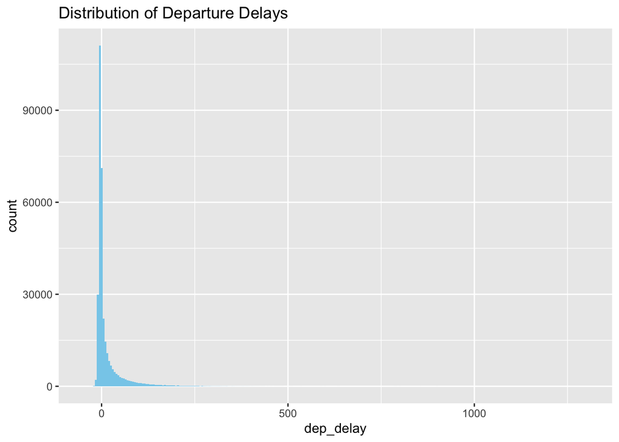

```r
ggplot(flights_weather, aes(x = dep_delay)) +
  geom_histogram(binwidth = 5, fill = "skyblue") +
  labs(title = "Distribution of Departure Delays")
```

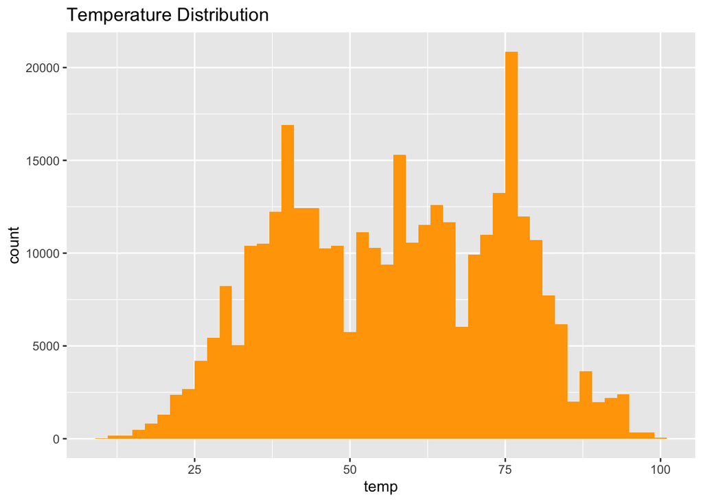

```r
ggplot(flights_weather, aes(x = temp)) +
  geom_histogram(binwidth = 2, fill = "orange") +
  labs(title = "Temperature Distribution")
```

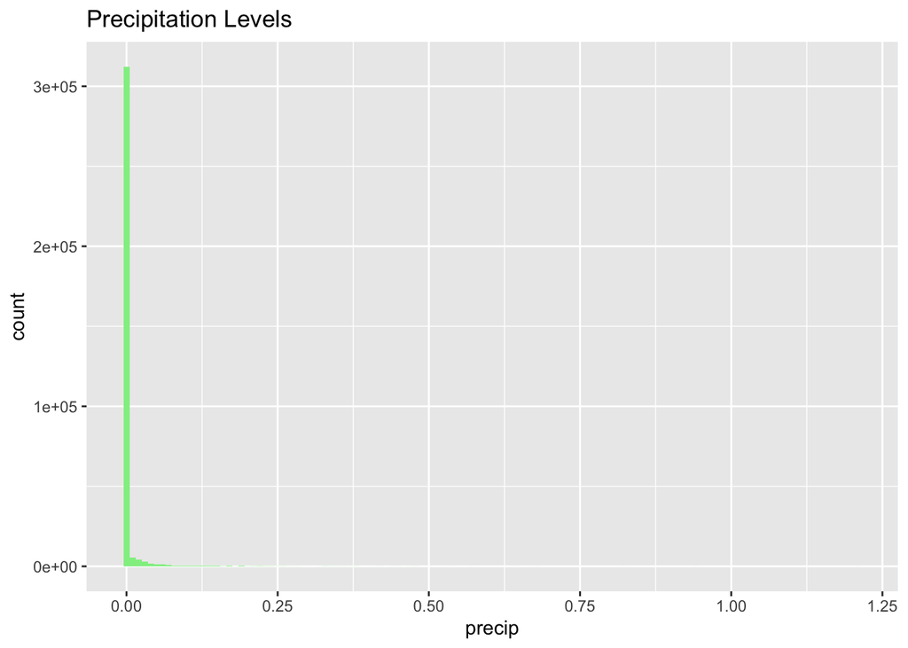

```r
ggplot(flights_weather, aes(x = precip)) +
  geom_histogram(binwidth = 0.01, fill = "lightgreen") +
  labs(title = "Precipitation Levels")
```

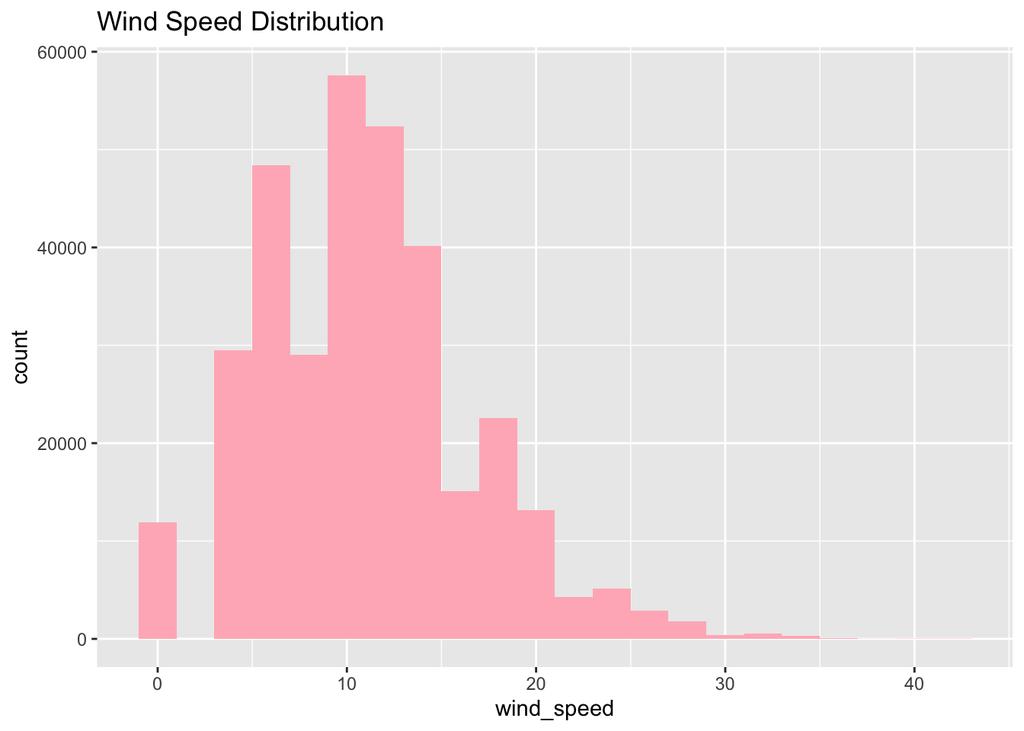

```r
ggplot(flights_weather, aes(x = wind_speed)) +
  geom_histogram(binwidth = 2, fill = "lightpink") +
  labs(title = "Wind Speed Distribution")
```

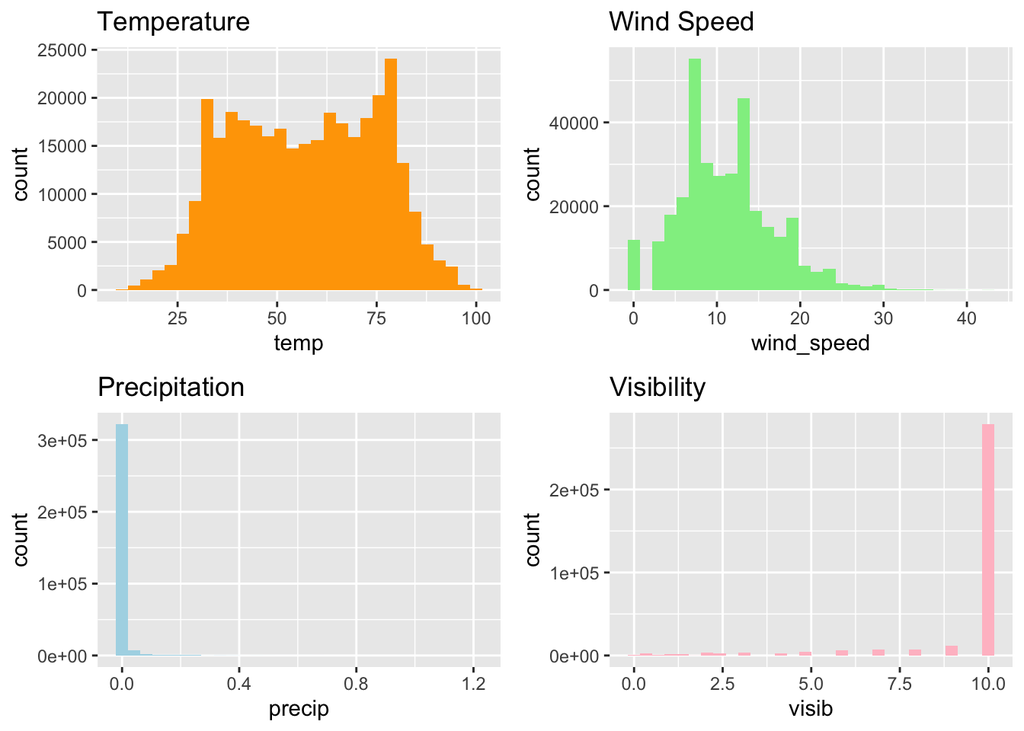

```r
library(gridExtra)
p1 <- ggplot(flights_weather, aes(x = temp)) + geom_histogram(fill = "orange") + ggtitle("Temperature")
p2 <- ggplot(flights_weather, aes(x = wind_speed)) + geom_histogram(fill = "lightgreen") + ggtitle("Wind Speed")
p3 <- ggplot(flights_weather, aes(x = precip)) + geom_histogram(fill = "lightblue") + ggtitle("Precipitation")
p4 <- ggplot(flights_weather, aes(x = visib)) + geom_histogram(fill = "pink") + ggtitle("Visibility")

grid.arrange(p1, p2, p3, p4, nrow = 2)
```

6: check expectations:

Higher precip → longer delays. Lower visib → longer delays. Stronger wind_gust → longer delays. temp may not have a direct effect.

7: validate with an external source Using NOAA 2013 NYC weather reports, we know: Major snowstorms occurred in February and March. Thunderstorms were frequent in July–August.These periods correspond to higher average flight delays — validating that weather events truly affect flight operations.

8: Do flights experience longer departure delays when precipitation increases?

9: solution:

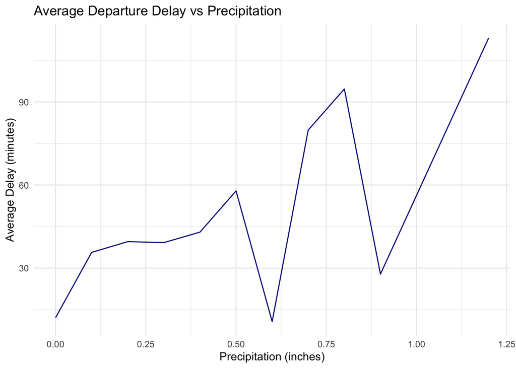

```r
flights_weather %>%
  mutate(precip_round = round(precip, 1)) %>%
  group_by(precip_round) %>%
  summarize(avg_delay = mean(dep_delay, na.rm = TRUE)) %>%
  ggplot(aes(x = precip_round, y = avg_delay)) +
  geom_line(color = "darkblue") +
  labs(
    title = "Average Departure Delay vs Precipitation",
    x = "Precipitation (inches)",
    y = "Average Delay (minutes)"
  ) +
  theme_minimal()
```

10. challenge solution: add in wind speed and visibility to test if precipitation alone explains delays:

```r
lm_model <- lm(dep_delay ~ precip + wind_speed + visib, data = flights_weather)
summary(lm_model)
```

```
Call:
lm(formula = dep_delay ~ precip + wind_speed + visib, data = flights_weather)

Residuals:
    Min      1Q  Median      3Q     Max
-122.38  -17.06  -13.04   -1.62 1289.09

Coefficients:
            Estimate Std. Error t value Pr(>|t|)
(Intercept) 22.77864    0.37264   61.13   <2e-16 ***
precip      86.68595    2.48957   34.82   <2e-16 ***
wind_speed   0.36943    0.01267   29.15   <2e-16 ***
visib       -1.57138    0.03737  -42.05   <2e-16 ***
---
Signif. codes:  0 '***' 0.001 '**' 0.01 '*' 0.05 '.' 0.1 ' ' 1

Residual standard error: 39.92 on 326911 degrees of freedom
  (9861 observations deleted due to missingness)
Multiple R-squared:  0.01547,   Adjusted R-squared:  0.01546
F-statistic:  1712 on 3 and 326911 DF,  p-value: < 2.2e-16
```

#7:

Average departure delay by day:

```r
avg_delay_day <- flights_weather %>%
  group_by(year, month, day) %>%
  summarize(avg_dep_delay = mean(dep_delay, na.rm = TRUE)) %>%
  arrange(desc(avg_dep_delay))
head(avg_delay_day, 1)
```

```
# A tibble: 1 × 4
# Groups:   year, month [1]
   year month   day avg_dep_delay
  <int> <int> <int>         <dbl>
1  2013     3     8          83.5
```

Ans: 2013-03-08 had the worst average departure delay, with an average of about 83 minutes.Bad weather in early March caused major flight disruptions across New York airports, leading to the longest daily average delay.

Average departure delay by day and airport:

```r
avg_delay_day_origin <- flights_weather %>%
  group_by(origin, year, month, day) %>%
  summarize(avg_dep_delay = mean(dep_delay, na.rm = TRUE)) %>%
  arrange(desc(avg_dep_delay))
head(avg_delay_day_origin, 1)
```

```
# A tibble: 1 × 5
# Groups:   origin, year, month [1]
  origin  year month   day avg_dep_delay
  <chr>  <int> <int> <int>         <dbl>
1 LGA     2013     3     8          106.
```

LaGuardia (LGA) on 2013-03-08 had the worst single day, with an average departure delay of about 100 minutes.LaGuardia’s smaller capacity makes it especially vulnerable to weather-related congestion.

Average departure delay by hour and origin:

```r
avg_delay_hour_origin <- flights %>%
  group_by(origin, year, month, day, hour) %>%
  summarize(avg_dep_delay = mean(dep_delay, na.rm = TRUE)) %>%
  arrange(desc(avg_dep_delay))
head(avg_delay_hour_origin, 1)
```

```
# A tibble: 1 × 6
# Groups:   origin, year, month, day [1]
  origin  year month   day  hour avg_dep_delay
  <chr>  <int> <int> <int> <dbl>         <dbl>
1 LGA     2013     7    28    21          280.
```

The worst single hour for delays occurred at LaGuardia Airport (LGA) on July 28, 2013 at 9 PM, with an average delay of about 280 minutes (≈ 4.7 hours).

#8:

```r
avg_delay_dest <- flights_weather %>%
  group_by(dest) %>%
  summarise(avg_dep_delay = mean(dep_delay, na.rm = TRUE))

airports_delay <- airports %>%
  left_join(avg_delay_dest, by = c("faa" = "dest"))
head(airports_delay)
```

```
# A tibble: 6 × 9
  faa   name                     lat   lon   alt    tz dst   tzone avg_dep_delay
  <chr> <chr>                  <dbl> <dbl> <dbl> <dbl> <chr> <chr>         <dbl>
1 04G   Lansdowne Airport       41.1 -80.6  1044    -5 A     Amer…            NA
2 06A   Moton Field Municipal…  32.5 -85.7   264    -6 A     Amer…            NA
3 06C   Schaumburg Regional     42.0 -88.1   801    -6 A     Amer…            NA
4 06N   Randall Airport         41.4 -74.4   523    -5 A     Amer…            NA
5 09J   Jekyll Island Airport   31.1 -81.4    11    -5 A     Amer…            NA
6 0A9   Elizabethton Municipa…  36.4 -82.2  1593    -5 A     Amer…            NA
```

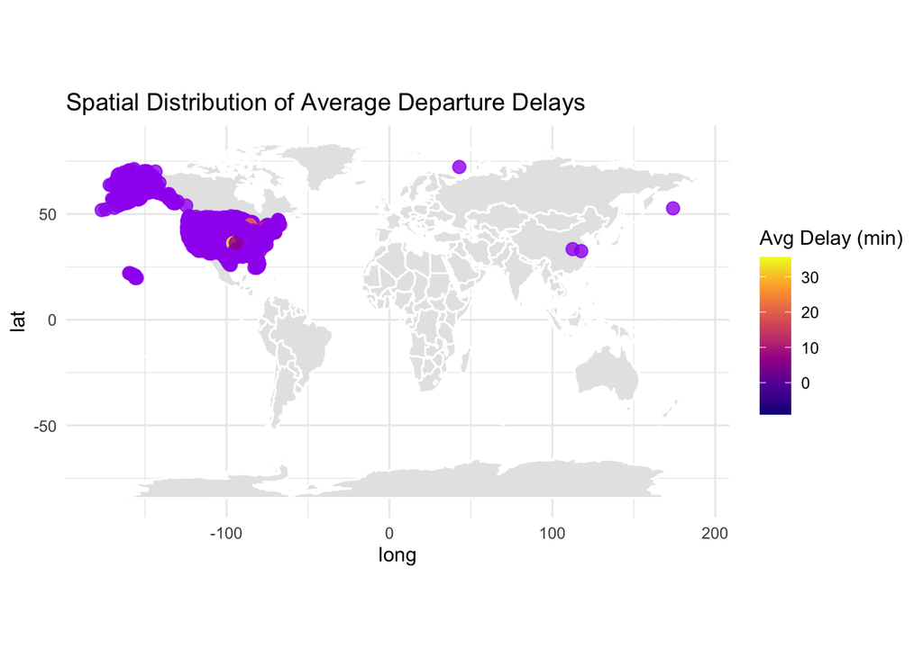

```r
library(ggplot2)
library(maps)
world_map <- map_data("world")
ggplot() +
  geom_polygon(
    data = world_map, aes(x = long, y = lat, group = group),
    fill = "gray90", color = "white"
  ) +
  geom_point(
    data = airports_delay,
    aes(x = lon, y = lat, color = avg_dep_delay),
    size = 3, alpha = 0.8
  ) +
  scale_color_viridis_c(option = "plasma", na.value = "purple") +
  coord_fixed(1.3) +
  labs(
    title = "Spatial Distribution of Average Departure Delays",
    color = "Avg Delay (min)"
  ) +
  theme_minimal()
```

US airports only:

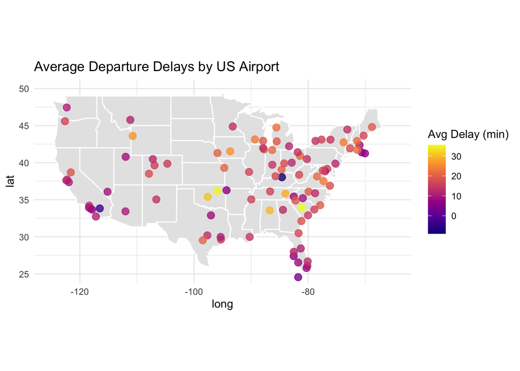

```r
ggplot() +
  geom_polygon(
    data = map_data("state"), aes(x = long, y = lat, group = group),
    fill = "gray90", color = "white"
  ) +
  geom_point(
    data = airports_delay %>% filter(!is.na(avg_dep_delay)),
    aes(x = lon, y = lat, color = avg_dep_delay),
    size = 3, alpha = 0.8
  ) +
  scale_color_viridis_c(option = "plasma") +
  coord_fixed(1.3, xlim = c(-125, -65), ylim = c(25, 50)) +
  labs(title = "Average Departure Delays by US Airport", color = "Avg Delay (min)") +
  theme_minimal()
```

```r
library(dplyr)
library(nycflights13)
library(leaflet)

avg_delay_dest <- flights_weather %>%
  group_by(dest) %>%
  summarise(avg_dep_delay = mean(dep_delay, na.rm = TRUE))

airports_delay <- airports %>%
  left_join(avg_delay_dest, by = c("faa" = "dest"))

airports_delay <- airports_delay %>% filter(!is.na(avg_dep_delay))

leaflet(airports_delay) %>%
  addTiles() %>%
  addCircleMarkers(
    lng = ~lon,
    lat = ~lat,
    radius = 5,
    color = ~colorNumeric("plasma", avg_dep_delay)(avg_dep_delay),
    stroke = FALSE,
    fillOpacity = 0.8,
    label = ~paste0(name, " (", faa, "): ", round(avg_dep_delay, 1), " min")
  ) %>%
  addLegend(
    "bottomright",
    pal = colorNumeric("plasma", airports_delay$avg_dep_delay),
    values = airports_delay$avg_dep_delay,
    title = "Avg Departure Delay (min)",
    opacity = 1
  )
```

[interactive chart not shown]

#9:

```r
flights_weather <- flights_weather %>%
  mutate(
    temp_cat = case_when(
      temp < 40 ~ "Cold (<40°F)",
      temp < 70 ~ "Mild (40–70°F)",
      TRUE      ~ "Warm (>70°F)"
    ),
    wind_cat = case_when(
      wind_speed < 10 ~ "Calm (<10 mph)",
      wind_speed < 20 ~ "Moderate (10–20 mph)",
      TRUE            ~ "Windy (>20 mph)"
    ),
    visib_cat = case_when(
      visib < 2 ~ "Low (<2 mi)",
      visib < 5 ~ "Moderate (2–5 mi)",
      TRUE      ~ "High (>5 mi)"
    ),
    precip_cat = case_when(
      precip == 0 ~ "No Precip",
      precip < 0.2 ~ "Light Precip",
      TRUE         ~ "Heavy Precip"
    )
  )
```

```r
delay_summary <- flights_weather %>%
  summarise(
    mean_delay = mean(dep_delay, na.rm = TRUE),
    median_delay = median(dep_delay, na.rm = TRUE),
    max_delay = max(dep_delay, na.rm = TRUE),
    min_delay = min(dep_delay, na.rm = TRUE)
  )
delay_summary
```

```
  mean_delay median_delay max_delay min_delay
1   12.63907           -2      1301       -43
```

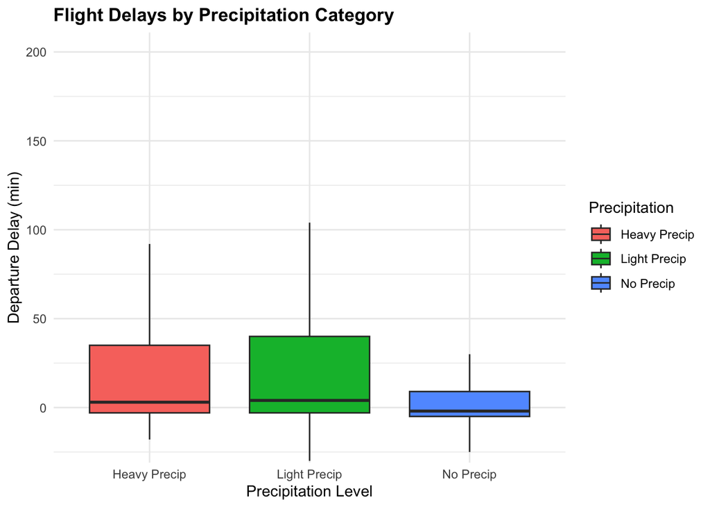

```r
ggplot(flights_weather, aes(x = precip_cat, y = dep_delay, fill = precip_cat)) +
  geom_boxplot(outlier.shape = NA) +
  coord_cartesian(ylim = c(-20, 200)) +
  labs(
    title = "Flight Delays by Precipitation Category",
    x = "Precipitation Level",
    y = "Departure Delay (min)",
    fill = "Precipitation"
  ) +
  theme_minimal(base_size = 11) +
  theme(plot.title = element_text(size = 13, face = "bold"))
```

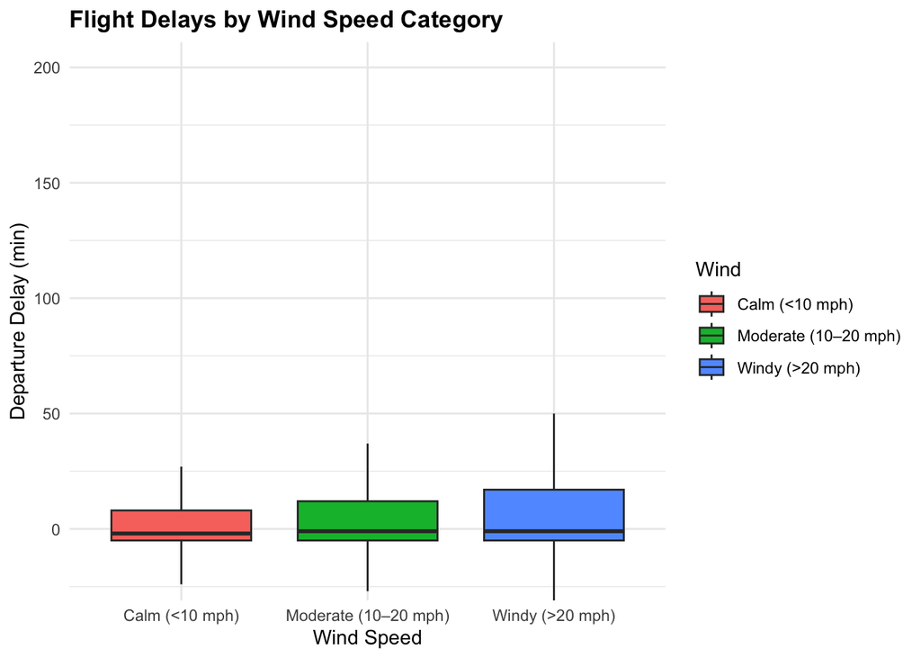

```r
ggplot(flights_weather, aes(x = wind_cat, y = dep_delay, fill = wind_cat)) +
  geom_boxplot(outlier.shape = NA) +
  coord_cartesian(ylim = c(-20, 200)) +
  labs(
    title = "Flight Delays by Wind Speed Category",
    x = "Wind Speed",
    y = "Departure Delay (min)",
    fill = "Wind"
  ) +
  theme_minimal(base_size = 11) +
  theme(plot.title = element_text(size = 13, face = "bold"))
```

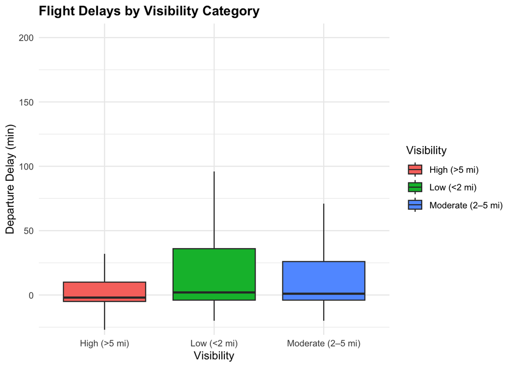

```r
ggplot(flights_weather, aes(x = visib_cat, y = dep_delay, fill = visib_cat)) +
  geom_boxplot(outlier.shape = NA) +
  coord_cartesian(ylim = c(-20, 200)) +
  labs(
    title = "Flight Delays by Visibility Category",
    x = "Visibility",
    y = "Departure Delay (min)",
    fill = "Visibility"
  ) +
  theme_minimal(base_size = 11) +
  theme(plot.title = element_text(size = 13, face = "bold"))
```

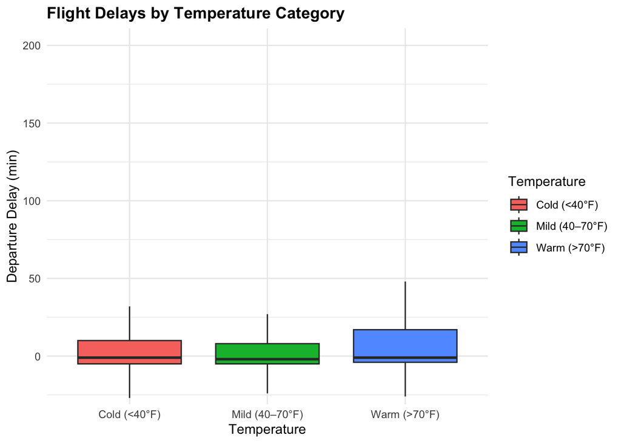

```r
ggplot(flights_weather, aes(x = temp_cat, y = dep_delay, fill = temp_cat)) +
  geom_boxplot(outlier.shape = NA) +
  coord_cartesian(ylim = c(-20, 200)) +
  labs(
    title = "Flight Delays by Temperature Category",
    x = "Temperature",
    y = "Departure Delay (min)",
    fill = "Temperature"
  ) +
  theme_minimal(base_size = 11) +
  theme(plot.title = element_text(size = 13, face = "bold"))
```

```r
flights_weather %>%
  summarise(
    avg_delay = mean(dep_delay, na.rm = TRUE),
    avg_temp = mean(temp, na.rm = TRUE),
    avg_wind = mean(wind_speed, na.rm = TRUE),
    avg_visib = mean(visib, na.rm = TRUE),
    avg_precip = mean(precip, na.rm = TRUE)
  )
```

```
  avg_delay avg_temp avg_wind avg_visib  avg_precip
1  12.63907 56.99647 11.11429  9.255656 0.004563809
```

```r
weather_corr <- flights_weather %>%
  select(dep_delay, temp, wind_speed, visib, precip) %>%
  cor(use = "complete.obs")

round(weather_corr, 2)
```

```
           dep_delay  temp wind_speed visib precip
dep_delay       1.00  0.06       0.05 -0.09   0.09
temp            0.06  1.00      -0.14  0.09   0.01
wind_speed      0.05 -0.14       1.00  0.07   0.03
visib          -0.09  0.09       0.07  1.00  -0.32
precip          0.09  0.01       0.03 -0.32   1.00
```

Delay vs Temperature:

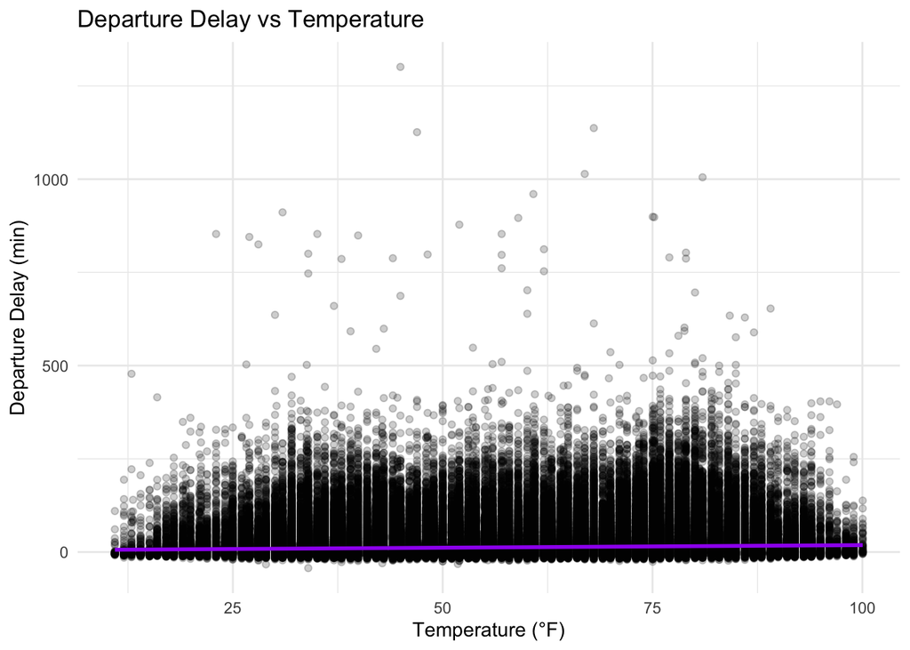

```r
ggplot(flights_weather, aes(x = temp, y = dep_delay)) +
  geom_point(alpha = 0.2) +
  geom_smooth(method = "lm", color = "purple") +
  labs(
    title = "Departure Delay vs Temperature",
    x = "Temperature (°F)",
    y = "Departure Delay (min)"
  ) +
  theme_minimal()
```

Delay vs Wind Speed

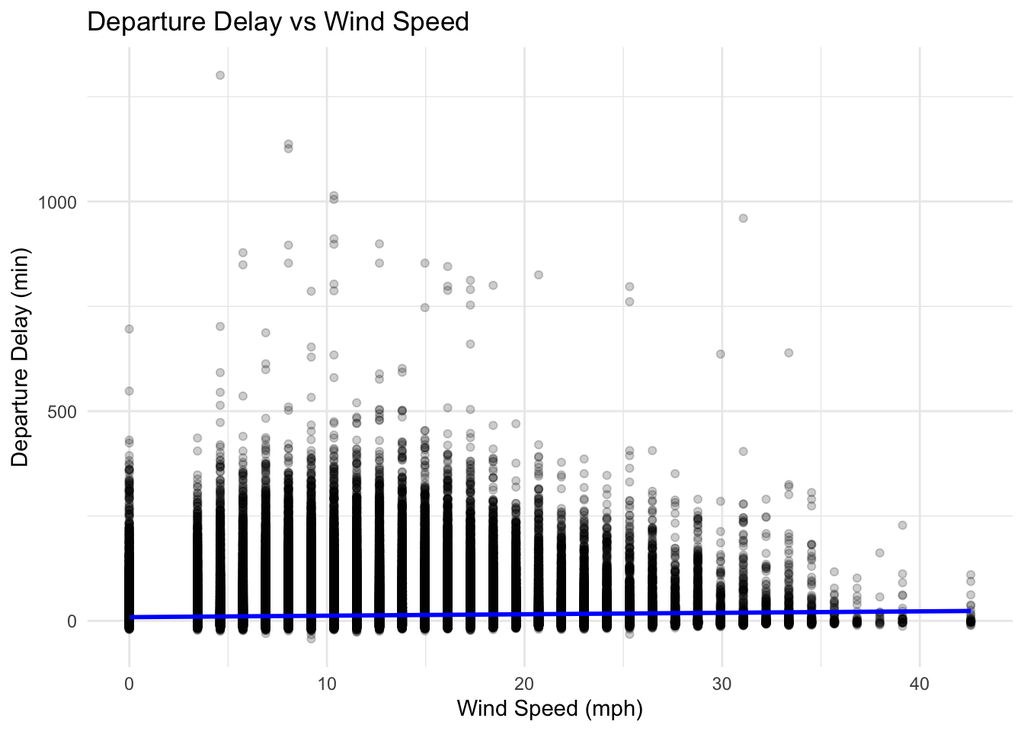

```r
ggplot(flights_weather, aes(x = wind_speed, y = dep_delay)) +
  geom_point(alpha = 0.2) +
  geom_smooth(method = "lm", color = "blue") +
  labs(
    title = "Departure Delay vs Wind Speed",
    x = "Wind Speed (mph)",
    y = "Departure Delay (min)"
  ) +
  theme_minimal()
```

Delay vs Visibility

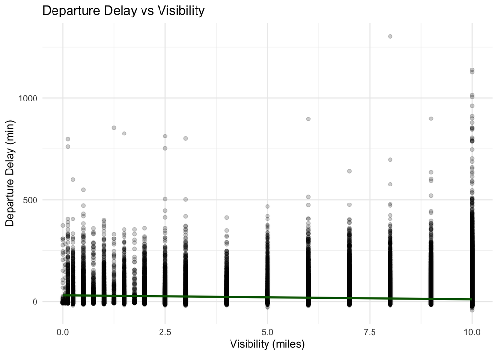

```r
ggplot(flights_weather, aes(x = visib, y = dep_delay)) +
  geom_point(alpha = 0.2) +
  geom_smooth(method = "lm", color = "darkgreen") +
  labs(
    title = "Departure Delay vs Visibility",
    x = "Visibility (miles)",
    y = "Departure Delay (min)"
  ) +
  theme_minimal()
```

Delay vs Precipitation

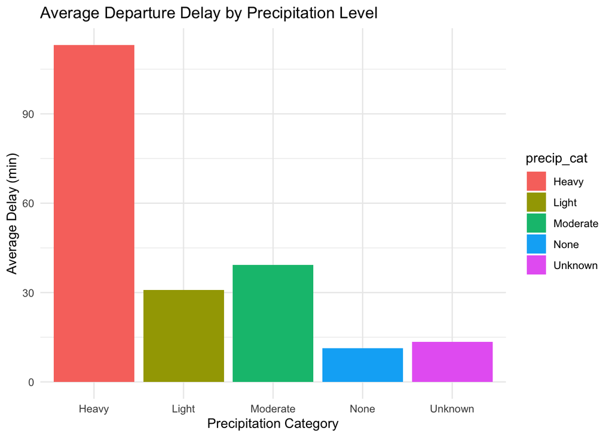

```r
flights_weather <- flights_weather %>%
  mutate(
    precip_cat = case_when(
      precip == 0 ~ "None",
      precip > 0 & precip <= 0.5 ~ "Light",
      precip > 0.5 & precip <= 1.0 ~ "Moderate",
      precip > 1.0 ~ "Heavy",
      TRUE ~ "Unknown"
    )
  )

flights_weather %>%
  group_by(precip_cat) %>%
  summarise(avg_delay = mean(dep_delay, na.rm = TRUE)) %>%
  ggplot(aes(x = precip_cat, y = avg_delay, fill = precip_cat)) +
  geom_col() +
  labs(
    title = "Average Departure Delay by Precipitation Level",
    x = "Precipitation Category",
    y = "Average Delay (min)"
  ) +
  theme_minimal()
```

```r
library(ggplot2)
library(dplyr)
library(viridis)
```

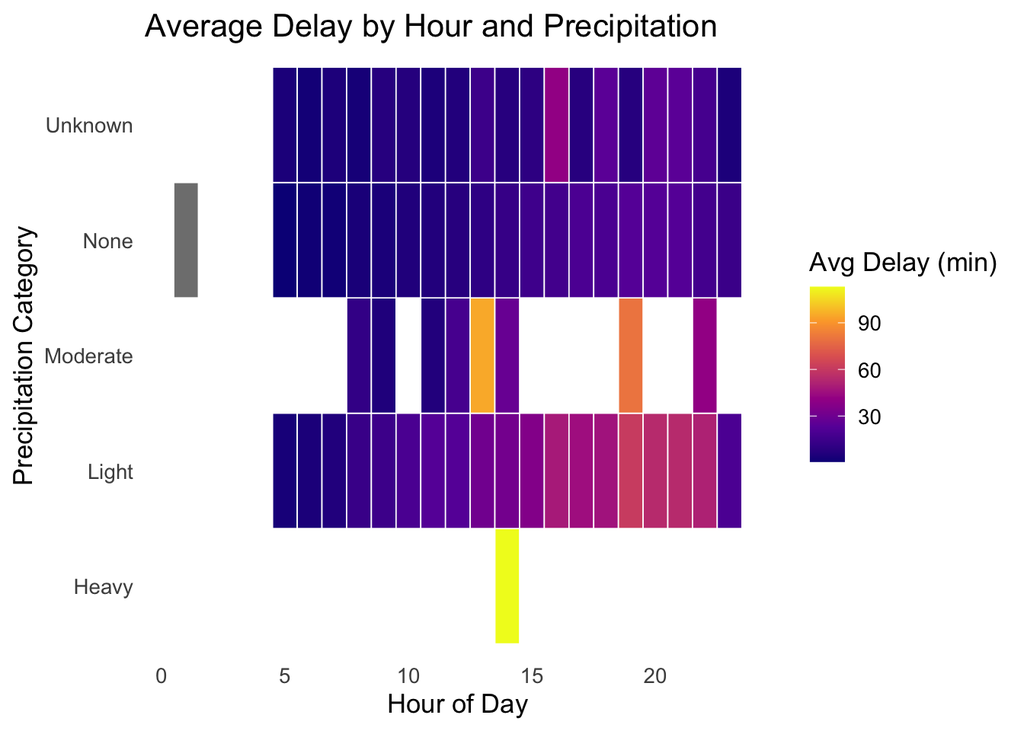

```r
flights_weather %>%
  group_by(hour, precip_cat) %>%
  summarise(avg_delay = mean(dep_delay, na.rm = TRUE)) %>%
  ggplot(aes(x = hour, y = precip_cat, fill = avg_delay)) +
  geom_tile(color = "white", linewidth = 0.3) +
  scale_fill_viridis_c(option = "C") +
  labs(
    title = "Average Delay by Hour and Precipitation",
    x = "Hour of Day", y = "Precipitation Category", fill = "Avg Delay (min)"
  ) +
  theme_minimal(base_size = 13) +
  theme(panel.grid = element_blank())
```

Weather phenomena that most impact flight delays are precipitation and low visibility, with heavy rain/snow days showing the largest average departure delays. Wind also contributes but to a lesser extent, while temperature alone is not a major driver.